# How to maintain a good relationship (A guide book of how to make your girlfriend happy)

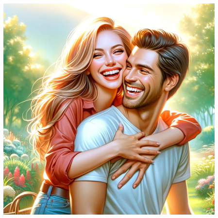

This report is a guidebook with selected Q&A aims at finding out the best way to make your girlfriend happy.

The whole dataset: HappyDB is a corpus of 100,000 crowd-sourced happy moments via Amazon’s Mechanical Turk, which could be read more on https://arxiv.org/abs/1801.07746.

This report is prepared with the following environmental settings.

```
Python version
3.8.8 (default, Apr 13 2021, 15:08:03) [MSC v.1916 64 bit (AMD64)]
Version info.
sys.version_info(major=3, minor=8, micro=8, releaselevel='final', serial=0)
```

# Question #1 : Does your girlfriend value your achivement?

At the age of 17, when I was a high school kid, there was a beautiful girl in my class who I was obsessed with. I tried hard to get higher grade to draw her attention. However, she got in relationship with the little rascal with yellow hair in my class. I was really confused and kept asking myself the same question everyday: where did I lose? Several years later, I finally find the answer and the results are shown below.

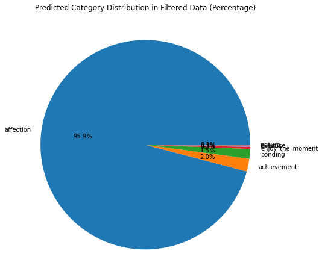

From the chart above, 96% happiness comes from the affection provided by boyfriends while achievement only takes 2%. It is obvious that it is not the achievement that makes a girl happy but affection, which remind me the days that the little rascal took my favorite girl for a ride along the shore, enjoying the breeze from the sea. Every their post on social media I stalked still appears in my mind nowadays.

This result also gives insghts on how to date with a girl you like: do not talk too much on what achievement you've made or how successful you are on your career path because girls do not care about it, moreover, they may see this as distasteful showing off. Instead, talk more about fun stories happened on you. It could be an embarrasing experience when you were a kid, some fantastic places you have been to, or interesting people you've met.

# Question #2: What kind of activity does your girlfriend like the most?

After learning to devote in providing the girl I like with affection, I finally got my first love in my college. But another obstacle blocked my way: I don't know what activity she likes. I took her to my favorite basketball game in LA, Lakers vs Warriors, but she did not seem happy about it.I wonder why, since it was a fantastic match. Then I find the top 10 frequent nouns,verbs and adjectives and combining them together, I discover that preparing a pleasant dinner is what bring a girl happiness.

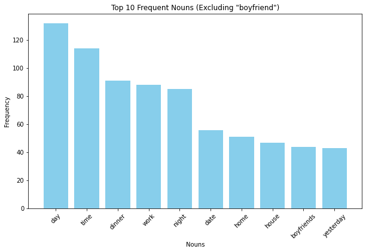

Here are 10 sample responses related to my findings. We can see making food occurs 5 times.

```
19100    I discovered a scratch on my car while my boyf...
84100    Cooking dinner for my boyfriend and me made me...
22377                My boyfriend made me a delicious meal
19549    My boyfriend complemented me on the dinner I m...
70108    I was able to spend time with my boyfriend in ...
16349    What made me happy in the past 24 hours is tal...
32746    I watched Through the Looking Glass last night...
42716    It made me happy when I was able to surprise m...
80104    When I was first courting my girlfriend, it wa...
55106    My boyfriend made dinner for me since he got h...
Name: cleaned_hm, dtype: object
```

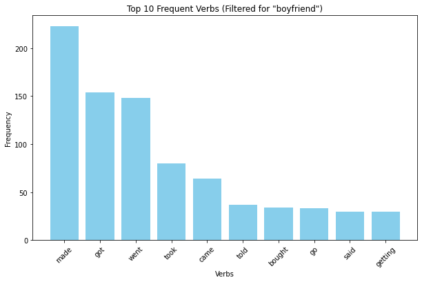

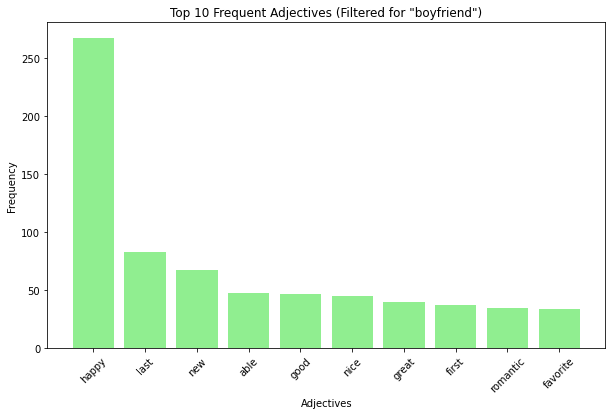

What does your girlfriend like on a date? The chart below shows 10 most popular activities related to entertainment, which gives you insights on planning a date. Watching movies, shows and concerts are top choices. Not surprising my girlfriend does not like watching a sport game with me.

[figure not shown]

# Question #3: What are the gifts that your girlfriend likes?

I always struggling about buying a gift for my girlfriend. I bought her lipsticks but she did not like the color; I bought her dress but she did not like the style; I bought her chocolates but she did not like the taste. What does she like as a gift? I find it out below: house, dinner, flowers, car. Houses and cars are too expensive while dinner and flowers seem more practical.

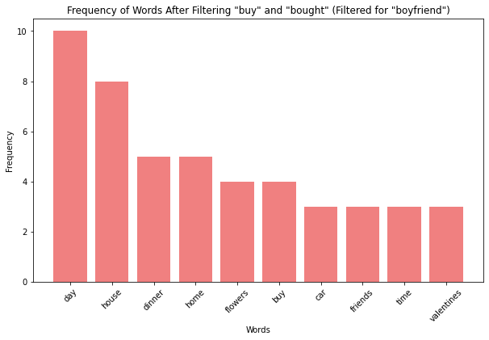

# Conclusion

In order to make your girlfriend happy,

1. Provide her affection.
1. A pleasant date: preparing nice dinner and watching movies, shows and concerts.
1. Buy her flowers